# RTG 2660: Evaluation 2022

Author

Sabrina Gado & Lea Hildebrandt

# RTG 2660 Approach-Avoidance

## First-year evaluation

A survey was created and distributed in September 2022 by the RTG coordinator and PhD representatives, assessing how satisfied the PhD researchers were with the first year of their PhDs within the RTG. Questions spanned both broader RTG-related topics (atmosphere, organization etc.) and teaching.

This evaluation was filled in by 15 PhD students of the RTG 2660. Approximately half of those were funded by the RTG, the other half is associated.

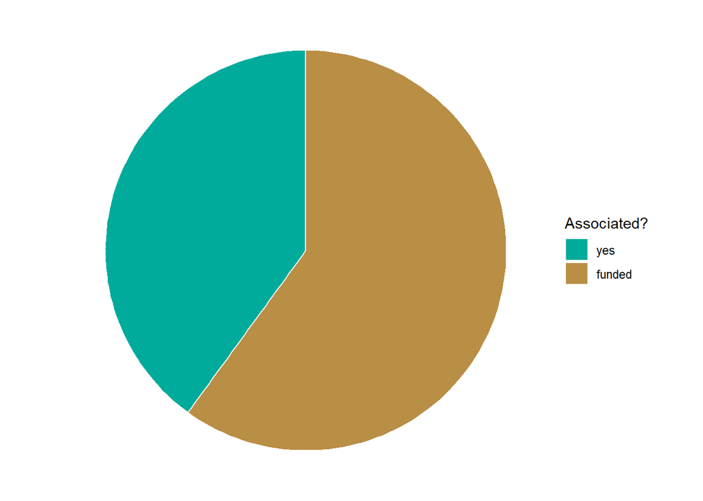

## General

We asked questions assessing both broader categories, such as the PhD researcher’s general impressions of the RTG, as well as specific categories such as teaching.

In general, the PhD researchers are happy to be part of the RTG and would recommend the RTG to others

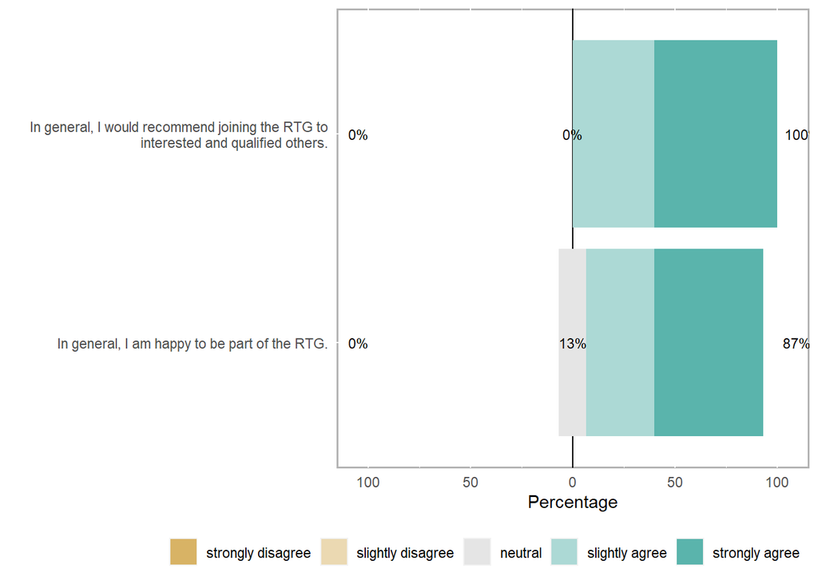

We also asked some open question for each category.

The general feedback is very broad. An important point is the wish that PIs should participate in the Jour Fixe. The PhDs also would like to have the animal research represented better.

> **General Feedback:**
- (I’m not sure if this is already implemented/taken into account) Since the majority of PhDs is working in human research, maybe it would be nice to have always at least one PhD of the animal researchers involved in decisions or as part of representation as well. If it is possible.
- It would be nice to have more PIs present at the jour fixe. We all invest some time in our presentations, and it can be discouraging to not get much feedback. More dinner meetings would be nice !
- I am really happy about the effort that is been taken to further improve the RTG - a big thanks to the coordinator! I am really thankful for the possibility to be part of this endeavour, and all the energy that is put into this!
- More basic research. Interdisciplinarity is important and relevant, but the talks or joux fixe of human researchers are a bit too out of scope for the animal researchers
- A clearer indication of what we can achieve in a typical 3-year RTG life

> **Maintain:**
- The open and friendly atmosphere :)
- Dinner Meetings Journal club
- The coordinator :) Lea is always there for us and provides help on so many aspects (organizational, personal, scientific, …) The slack room for communication
- The nice atmosphere. The whole group of the RTG provides a great and supportive enviroment.
- Interdisciplinary talks/opportunities
- The regular possibilities to exhange with the other students and Lea and Anna about the problems as PhD student (PhD assemblies, discussions after the jour fix…) and the very valuable support from Lea at any time the PhD representativ board is also very helfull and doing their job really well
- All the integrative environment.
- The Jour Fixe of course - it’s a great way to be in scientific exchange, to learn soft skills, and to socialize with fellow PhDs.
- The coordinators, the events and the funding opportunities.
- regular Jour Fixe
- supportive communication; the eye on inclusiveness and equaliy topics (i.e. funding opportunities for childcare etc.)
- Dinner meetings and regular meetings, that are not work-related. It is super nice to get to know each other outside the office/lab and form friendships within the RTG. I firmly believe this also leads to an atmosphere, where we can discuss research ideas and plans openly.
- Communiction between researchers from different fields (human researchers and animal researchers) and a friendly atmosphere.

## Atmosphere

We asked the PhD researchers for their general impression of the atmosphere within the RTG.

The responses show that PhD researchers generally appreciate the atmosphere but would like to have more (non-scientific) events organized for informal encounters.

It thus seems like the PhD researchers would like to have *more (leisure) events offered* by the RTG. (However, during the PhD Assembly, the time pressure was also mentioned as a reason not to attend too many events, which should be taken into account.)

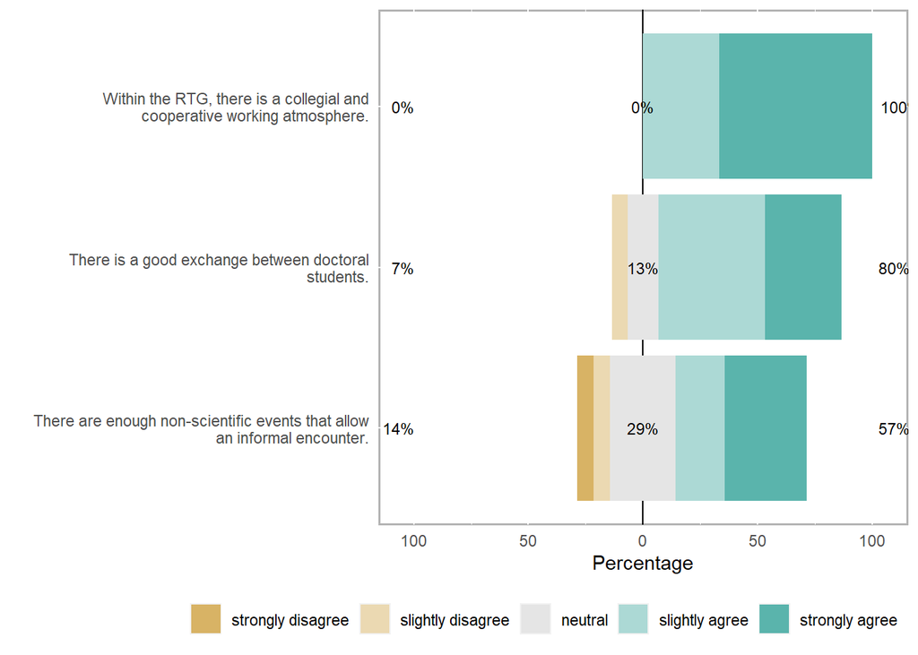

> **Atmosphere: I would wish for…**
- More chances to meet and talk, in an academic as well as a non-academic context. Basically it would be nice to have more events where we PhDs can discuss and integrate our research, but also more leisure time events. Maybe it would be even possible to organise some activities together, so we experience something together.
- Better virtual access to seminars (sometimes audio or video was not working)
- More fun activities ;)
- I would definitely wish for more opportunities to discuss research, but also meta-scientific aspects within the RTG (is translational research useful? what can we do to improve translational work? open science, ethics, …).
- More non-work related social events would be nice !
- more common memories
- nothing

## Communication

The communication within the RTG is rated as being inclusive and support when conflicts arise is satisfying.

Public (science) communication is alright, but less personal information should be shared online.

The question arises whether the information on the website is meant here or e.g. the introductions on Twitter. *This is a point for further investigation and increased sensitivity.*

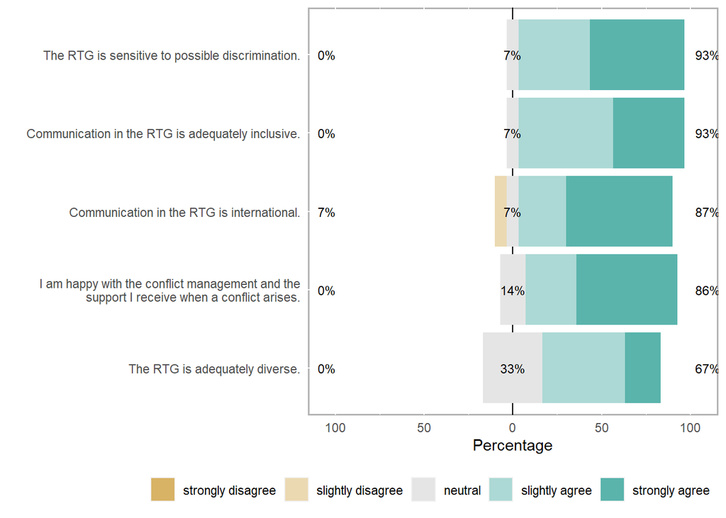

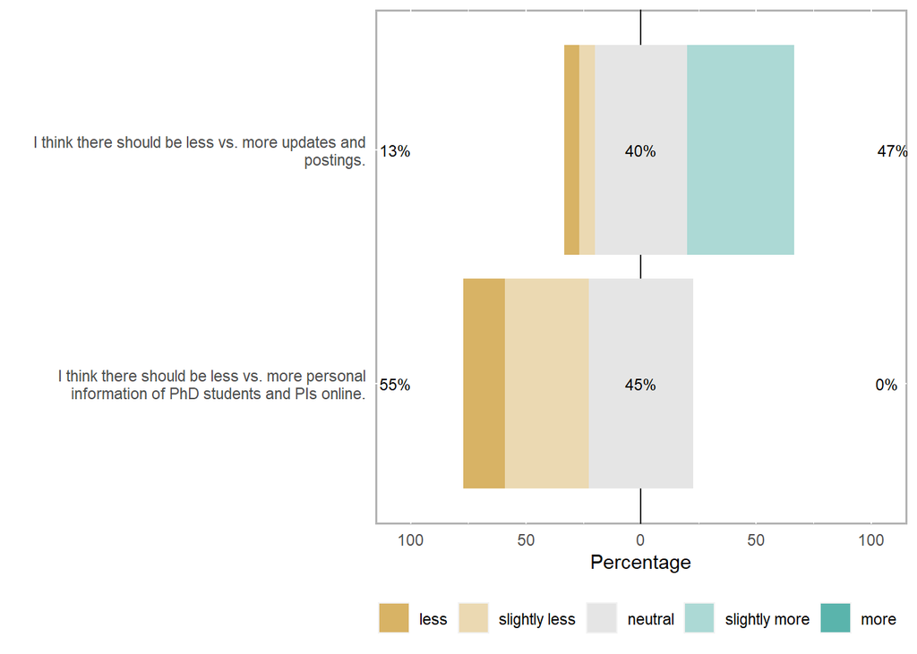

> **Communication: I would wish for…**
- In my opinion, communicating and justifying our research (and of course, why tax money should be spent to pay for us and our research) should be an integral part of the training of ECRs. Maybe a discussion on this topic and possible ““communication strategies”” (not everybody wants to use twitter or has his/her own blog) might at least show why publicity and communicating IS important.
- a more diverse presentation of the different labs and study fields within the RTG.
- sometimes a bit confusing which information is shared via Slack vs. Mail; general shift to MS Teams could make it more easy (but I am not sure about this)

## Organization

PhD students are in general very satisfied with the organization and have the impression that they are heard. The time pressure is also addressed. However, it is a bit unclear to ~ half what exactly is expected from them to obtain their PhDs. *This is likely due to it depending on the RTG’s requirements, the GSlS and of course the supervisor’s expectancies.*

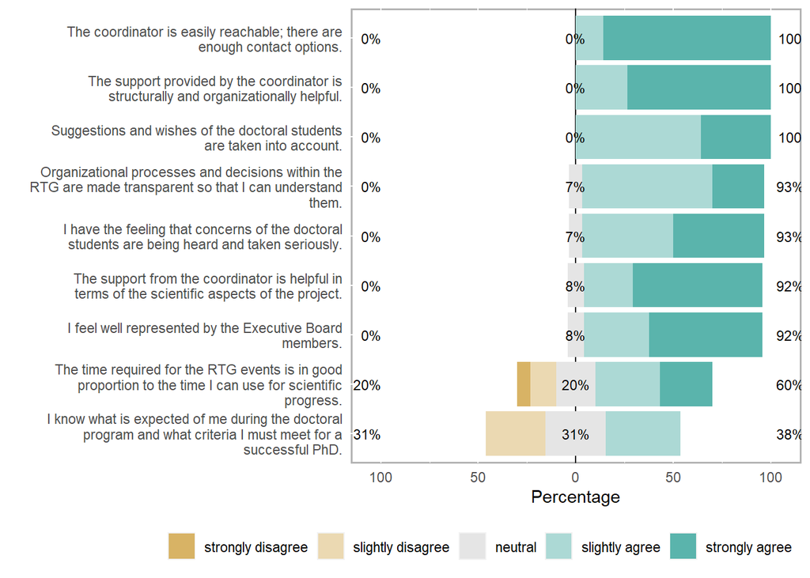

> **Organization: I would wish for…**
- more participation of the associated researchers (PhDs and PIs), but tbh I do not know how to arrange this
- more group sessions to synchronize expectations between other PhDs and the coordinator.
- I like thegood transparency, organization and supportive communication.

## Skills

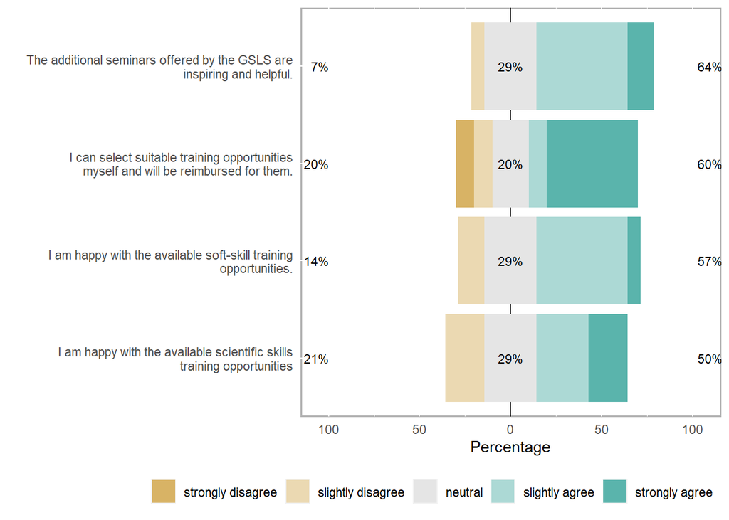

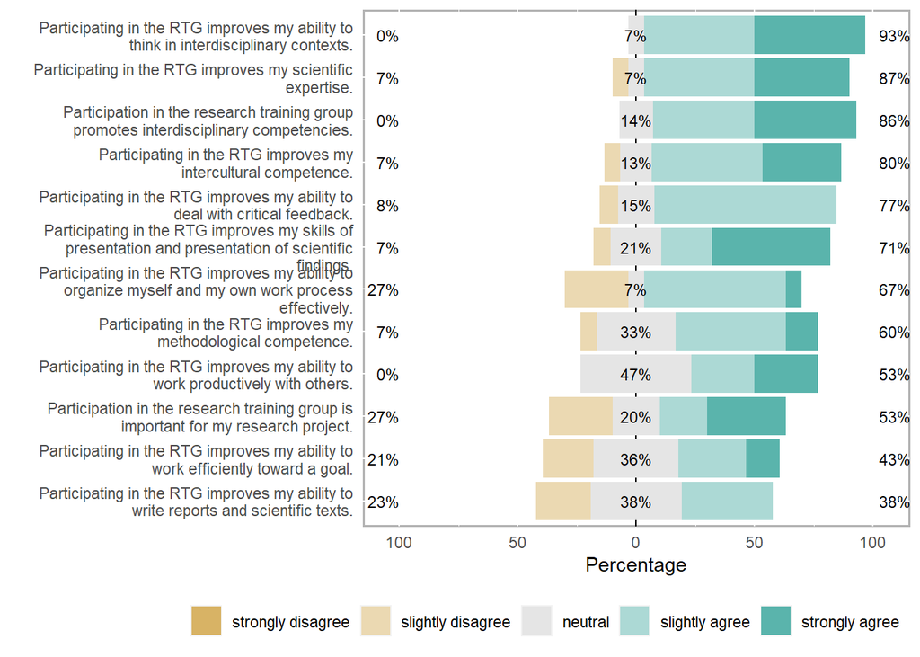

> **Skills: I wish for…**
- on the GSLS level it would be nice to have more availability/more spaces for certain courses and or seminars.
- I really apreciate the support and advice in general (for supervision problems, for organisation) I can get from the group (either the other students or Lea) this discussions I have in this context are really helpfull (especially the open discussion on the second half o the PhD assembly) On a scientific point of view as metioned before my project is outside AA, I get support only from one student from the programm because she has same type of work but since she is also in the same office I would have had her help also outside the RTG.

## Supervision

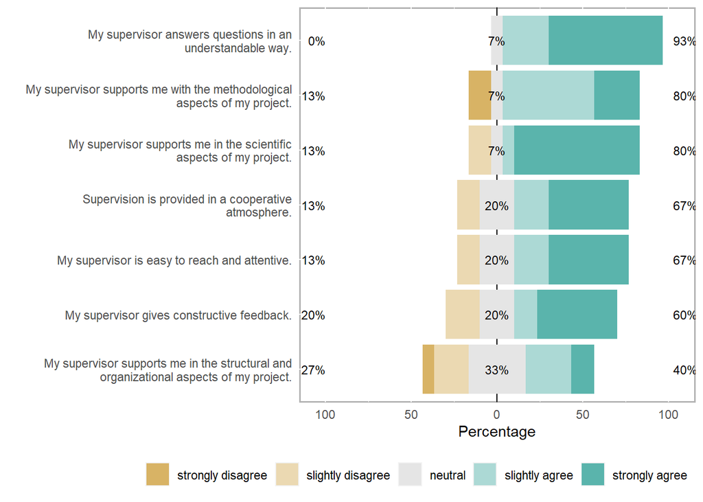

> **Supervision: I wish for…**
- I think it might sometimes be nice to have some regular meetings (yearly?) to talk about the current state of the dissertation project (like on a professional level), but also to receive some personal feedback regarding soft skills and the collaboration atmosphere between primary supervisor and PhD student
- knowing the expectations of my PI
- I feel like my project was not clearly defined at the beginning of the RTG, in the end, it overlaps with the projects of other PhD students and I sometimes feel like I don’t have my own PhD project but am only assisting with other projects.
- I already detailed my supervision problems to Lea and we tried to find some solutions together
- less pressure to achieve fast progress (unrealistic deadlines) and more trust and optimism for the development of the project. I would also wish for a bit more interest/openness for different ideas, even when they might lead to a side project. At the same time I am very thankful for the direction my supervisor gives me to keep me on track.

## Jour Fixe

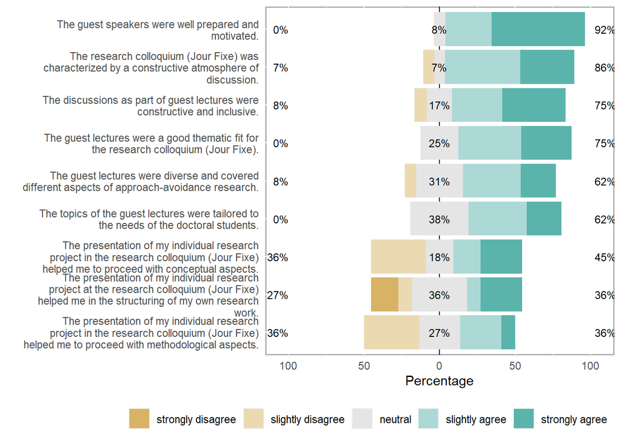

> **Jour Fixe: I wish for…**
- A different lecture hall. The echo in the current lecture hall is really strong and after a long day of work when you’re usually tired it is so hard to hear or concentrate on what is said because of the echo. Also, if you need to join remotely, it is basically impossible to follow any discussion because of the echo and sometimes it also makes it hard to hear the speaker.
- more female guest speaker
- We only had human researchers as guest speakers so far, so maybe some animal researchers / translational researchers would be fair :D (but that will be the case for the summer school)
- There was just one PI physically present when I presented, I would have enjoyed to get feedback from the PIs, which are not also my supervisors, to get some external input.
- As for the lecture/seminar, my topic is too different from other´s topics and from AA thus I did not received suggestions to improve my project but only questions for the audiance to understand better my project. Again, the problem comes I think from my project that does not fit this research training programm.
- for more diverse guest lectures, those were just not frequent enough.
- More basic science

## Teaching

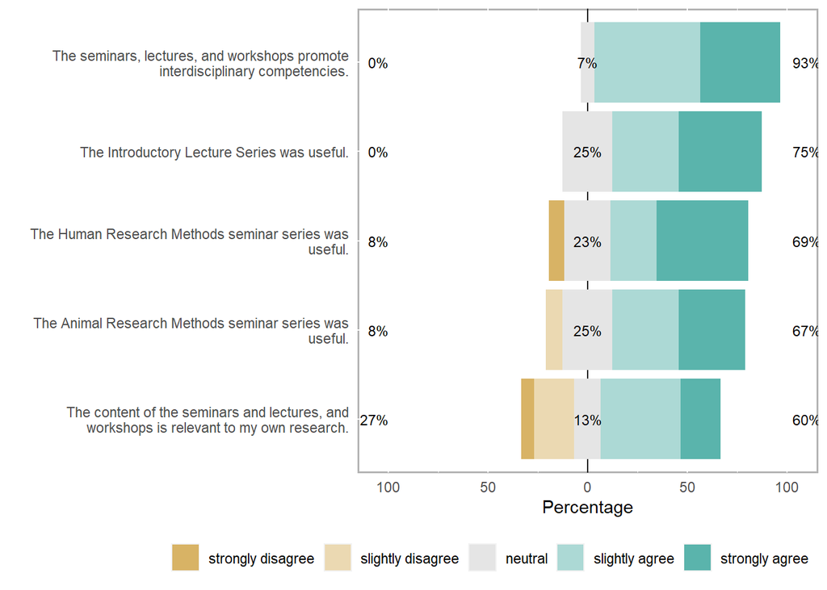

> **Teaching: I would wish for…**
- Some more availability of the PIs. I understand that PIs are insanely busy, but it would be great to have some advice/input of senior researchers, since they have much more experience and can support with improving our research and methodology thereby decreasing the likelihood of failed or flawed experimental designs.
- Maybe it would be interesting to have something like tandem sessions where two PIs (maybe animal and human researchers, but I guess this is not always possible or helpful) prepare a session on a topic together so that we can understand the similarities and differences in der points of view.
- if feasible, practical demonstrations of the methods would be nice
- More anatomy workshops !
- As I already mentioned to our representativ PhD students, the seminars and lectures are way too far from my research, thus they are only bringing me general knowledge but almost nothing for my research. This is probably not due to the lecture/seminar content but due to my project that is not adapted and not link to approach and avoidance
- some more practical sessions, e.g. with R (but I did not attend both semesters seminars..)

> **Teaching: My favorite seminar sessions were the sessions by…**
- Tovote, Pauli, because: You could follow their talk easily
- Eidel/Kbler, Tovote, Pauli, because: Eidel: very interesting demonstration (hands on), Tovote: brought pizza :D and optogenetics is just a crazy topic, Pauli: very interactive and high level
- Hein, Tovote, because: enthusiastic about their topics and very well paced
- Prof. Tovote, because: exchange
- Prof. Tovote, because: Optogenetics
- Grit Hein, because: She listed the things she would talk about it in the beginnig, and also the important things we should focus on. In my opinion, it is a great manner of guiding the students in absorve what is really important.
- Reiter, Tovote
- Animal seminars
- Matthias Gamer, because: eye tracking stuff, and general background of the project
- Andrea Reiter/Klara Gregorova, because: the hands on session in R, very well explained!

> **Teaching: This seminar could be improved…**
- Reiter, particularly in terms of: Understandability
- Schmitt-Bhrer, Lesch, particularly in terms of: more application-related or translational aspects
- Reiter, particularly in terms of: too much input, a bit hard to follow, looking at the R code in advance might have helped - but still a very good seminar!
- Prof. Reiter, particularly in terms of: pace
- It would have been nice to have more ““in person”” seminars and also to see some of the other labs !, particularly in terms of: The timeslot is not the best
- Angelika Schmitt, particularly in terms of: Didatic (straighforward), although she is a very kind person.

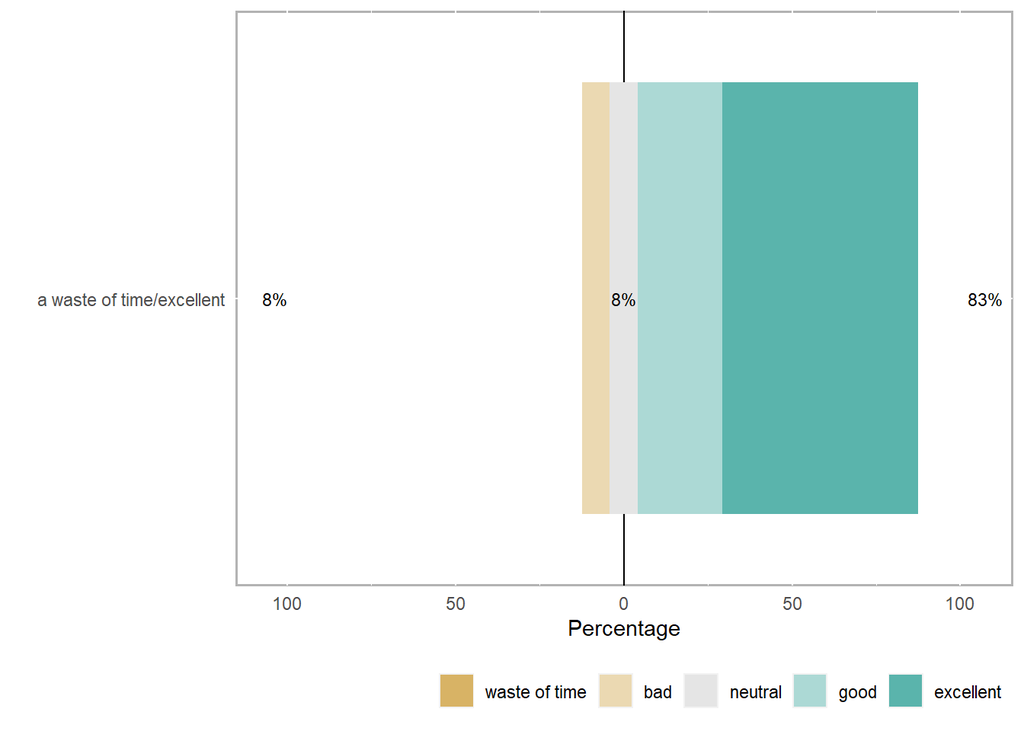

## Working Conditions

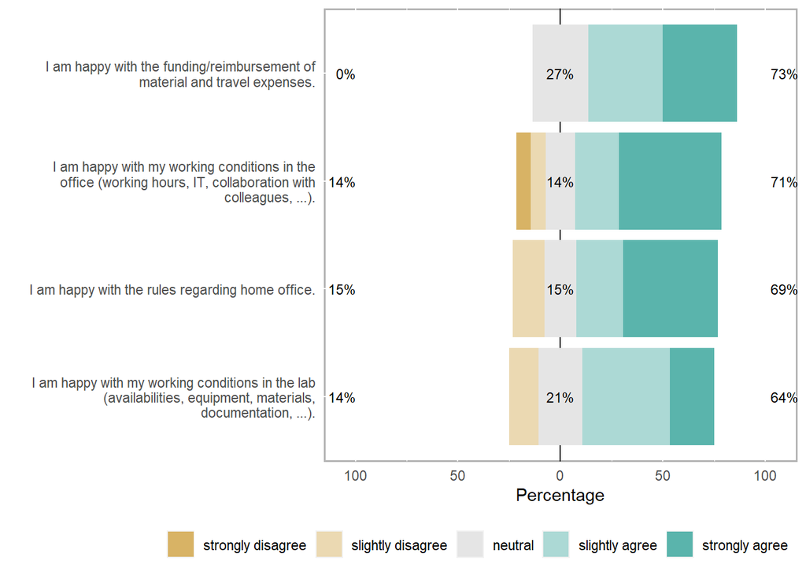

> **Office: I would like to change…**
- The insanely slow bureaucracy to organise anything related to my research. It hinders tbe progress of my project very badly.
- A fan would be nice !
- too big office (can be really loud sometimes or I am often interupted by people who ask me things when I am working (once I was analysing data with my student and someone interupted me to ask me to sign a wedding card and give money because I still did not have done it…)) no proper lunch space/relaxation space
- It would be nice to work in a smaller office. It would be great to have a mobile laptop instead of a stationary PC, to be able to leave the crowded big office, e.g. to work on a quite place, or for Zoom meetings.
- I want to have more communications with others.

> **Home Office: I would like to change…**
- Being able to work from home, when it’s not required to be in the office.
- I didn’t get specific instructions on how to manage remote working.
- I would like to be offered to work remotely whenever it fits better for me, unless my presence is needed at the office, e.g. for meetings. Most of the time I would anyways prefer to work in the office, but it would feel better, if I could feel more free in the decision.

> **Lab : I would like to change…**
- Having gloves available that actually protect me from the substances and chemicals that I use. The same goes for a lot of other saftey equipment. Also to have some sort of room temperature control (esp some form of air conditioning) available for the extreme temperatures in summer. It is in no way possible to work at temperatures above a certain threshold.
- Little support in the beginning, no w its ok
- some very old equipment (PCs…)